# 30535 Skills Problem Set 4

Hye-Min Jung

5/8/2020

This submission is my work alone and complies with the 30535 integrity policy. **Hye-Min Jung**  
Collaborators: M Samiul Prantar, Boseong Yun  
Late coins used this pset: 2. Late coins left: 7.

Follow the style guide including the new points on styling joins.

# 1 Exercises

## 1.1 Tidy data with pivot_wider() and pivot_longer()

1. Compute TB rate per 10000 people using table1, then table2, and finally table4a + table4b. The output is three identical tibbles with columns country, year and rate.
- **Which representation is easier to work with?**
  - `table1` is easiest to work with, since it is tidy dataset.
- **Which is harder?**
  - `table2` is harder and `table4a+table4b` is the hardest.
- **Why?**
  - Tidy dataset has (1) variables in columns, (2) observations in rows and (3) values in cells.
  - Among 3 datasets, only `table1` satisfied these rules, whereas both `table2` and `table4a+table4b` violated the rules.
  - `table2` has 1 problem: 1 observation in multiple rows. So I pivot wide `table` to make it tidy.
  - `table4a`, `talbe4b` have 2 problems: Data inside the columns names in `table4a`, `table4b` are pivoted long into a tidy form. Also, data were splitted acorss 2 tables. So I joined splited data using left_join.
  - On top of that, `table4a+table4b` had data even separated across two tables. So it was even hearder to work with.

```r
table1  %>%
   mutate(rate = cases / population * 10000 ) %>%
   select(country, year, rate)
```

```
## # A tibble: 6 x 3
##   country      year  rate
##   <chr>       <int> <dbl>
## 1 Afghanistan  1999 0.373
## 2 Afghanistan  2000 1.29
## 3 Brazil       1999 2.19
## 4 Brazil       2000 4.61
## 5 China        1999 1.67
## 6 China        2000 1.67
```

```r
table2 %>%
  pivot_wider(
    names_from = "type",
    values_from = "count"
    ) %>%
  mutate(rate = cases / population * 10000) %>%
  select(country, year, rate)
```

```
## # A tibble: 6 x 3
##   country      year  rate
##   <chr>       <int> <dbl>
## 1 Afghanistan  1999 0.373
## 2 Afghanistan  2000 1.29
## 3 Brazil       1999 2.19
## 4 Brazil       2000 4.61
## 5 China        1999 1.67
## 6 China        2000 1.67
```

```r
tidy4a <-
  table4a %>%
  pivot_longer(cols = `1999`:`2000`,
               names_to = "year",
               values_to = "cases")
tidy4b <-
  table4b %>%
  pivot_longer(cols = `1999`:`2000`,
               names_to = "year",
               values_to = "population")

left_join(tidy4a, tidy4b) %>%
  mutate(rate = cases / population * 10000) %>%
  select(country, year, rate)
```

```
## # A tibble: 6 x 3
##   country     year   rate
##   <chr>       <chr> <dbl>
## 1 Afghanistan 1999  0.373
## 2 Afghanistan 2000  1.29
## 3 Brazil      1999  2.19
## 4 Brazil      2000  4.61
## 5 China       1999  1.67
## 6 China       2000  1.67
```

2. pivot_wider() and pivot_longer() are not perfectly symmetrical. Carefully consider the following example.
- **Why do we need quotes on the arguments names_to and values_to, but not names_from and values_from?**
  - Because they do not exist in dataset, we need put names, values in quotes for the arguments for `names_to` and `values_to`,
  - Whereas, for `names_from` and `values_from`, we don’t need quotes on the arguments because it is existing column names

```r
stocks <- tibble(
  year = c(2015, 2015, 2016, 2016),
  half = c(1, 2, 1, 2),
  return = c(1.88, 0.59, 0.92, 0.17)
)

stocks %>%
  pivot_wider(names_from = year, values_from = return) %>%
  pivot_longer('2015':'2016', names_to = "year", values_to = "return")
```

```
## # A tibble: 4 x 3
##    half year  return
##   <dbl> <chr>  <dbl>
## 1     1 2015    1.88
## 2     1 2016    0.92
## 3     2 2015    0.59
## 4     2 2016    0.17
```

3. This code fails.
- **Explain the error message.**
  - `Error in inds_combine(.vars. ind_list) : Position must be between 0 and n`
  - This error message suggests there is a problem with using the range of columns.
  - resource : https://www.reddit.com/r/rstats/comments/dcassr/average_by_group_of_variables_code_used_to_work/
- **How could it be fixed?**
  - Errors can be fixed by putting backticks for column names. (1999:2000 to `1999`:`2000`)
  - resource : https://stackoverflow.com/questions/32512501/gather-with-tidyr-position-must-be-between-0-and-n-error

```r
table4a %>%
  pivot_longer('1999':'2000', names_to = "year", values_to = "cases")
```

```
## # A tibble: 6 x 3
##   country     year   cases
##   <chr>       <chr>  <int>
## 1 Afghanistan 1999     745
## 2 Afghanistan 2000    2666
## 3 Brazil      1999   37737
## 4 Brazil      2000   80488
## 5 China       1999  212258
## 6 China       2000  213766
```

- **4. Why does pivot_wider fail on this tibble?**
  - Since we have 2 rows with age, height for “Phillip Woods” but 1 rows for each for “Jessica Cordero”, `pivot_wider` fails on this tibble, because name and key columns do not uniquely identify rows.
  - This issue can be resolved by adding a new column to account for observation numbers. We could solve the problem by adding a row with a distinct observation count for each combination of name and key.
- **Add a new column to address the problem and show that pivot_wider works on your new updated dataset.**

```r
people <- tribble(
  ~name,            ~key,    ~value, ~observation,
  #-----------------|--------|------|-------------
  "Phillip Woods", "age", 45, 1,
  "Phillip Woods", "height", 186, 1,
  "Phillip Woods", "age", 50, 2,
  "Phillip Woods", "height", 185, 2,
  "Jessica Cordero", "age", 37, 1,
  "Jessica Cordero", "height", 156, 1,
)
people
```

```
## # A tibble: 6 x 4
##   name            key    value observation
##   <chr>           <chr>  <dbl>       <dbl>
## 1 Phillip Woods   age       45           1
## 2 Phillip Woods   height   186           1
## 3 Phillip Woods   age       50           2
## 4 Phillip Woods   height   185           2
## 5 Jessica Cordero age       37           1
## 6 Jessica Cordero height   156           1
```

```r
people %>%
  pivot_wider(names_from = "key",
              values_from = "value")
```

```
## # A tibble: 3 x 4
##   name            observation   age height
##   <chr>                 <dbl> <dbl>  <dbl>
## 1 Phillip Woods             1    45    186
## 2 Phillip Woods             2    50    185
## 3 Jessica Cordero           1    37    156
```

5. Tidy the pivot table below.
- **Do you need to make it wider or longer?**
  - We need to make it longer to make each variable is in its own column.
- **What are the variables?**
  - Variables are `pregnant`, `gender`, `count`

```r
preg <- tribble(
  ~pregnant, ~male, ~female,
  "yes", NA, 10,
  "no", 20, 12
)

preg %>%
  pivot_longer(cols ='male':'female',
               names_to = "gender",
              values_to = "count")
```

```
## # A tibble: 4 x 3
##   pregnant gender count
##   <chr>    <chr>  <dbl>
## 1 yes      male      NA
## 2 yes      female    10
## 3 no       male      20
## 4 no       female    12
```

- **6. What do the extra and fill arguments do in separate()?**
  - `extra` discard additional pieces/drop extra values.
  - `fill` fills missing pieces with `NA` if there are not enought pieces.

```r
tibble(x = c("a,b,c", "d,e,f,g", "h,i,j,extra")) %>%
  separate(x, c("one", "two", "three"), extra = "warn")
```

```
## # A tibble: 3 x 3
##   one   two   three
##   <chr> <chr> <chr>
## 1 a     b     c
## 2 d     e     f
## 3 h     i     j
```

```r
tibble(x = c("a,b,c", "d,e", "f,g,i")) %>%
  separate(x, c("one", "two", "three"), fill = "warn")
```

```
## # A tibble: 3 x 3
##   one   two   three
##   <chr> <chr> <chr>
## 1 a     b     c
## 2 d     e     <NA>
## 3 f     g     i
```

## 1.2 tidying case study

1. In this WHO case study in Ch 12.6 Hadley set na.rm = TRUE just to make it easier to check that we had the correct values.

1-1.

- **Are there implicit missing values?**
  - Yes, there are implicit missing values.
  - Because #of rows for who with complete cases of (country, year) 7446 > #of rows in who 7240
- **If there are implicit missing values, how many rows? If not, show how you know that there are not.**
  - 206 rows are missing values.
  - 7446 is the number of rows for who after automatically completing for implicitly missing values with (country, year) combination.
  - 7240 is the number of rows data in who.

```r
who %>%
  nrow()
```

```
## [1] 7240
```

```r
who %>%
  complete(country, year) %>%
  nrow()
```

```
## [1] 7446
```

```r
7446-7240
```

```
## [1] 206
```

```r
who
```

```
## # A tibble: 7,240 x 60
##    country iso2  iso3   year new_sp_m014 new_sp_m1524 new_sp_m2534
##    <chr>   <chr> <chr> <int>       <int>        <int>        <int>
##  1 Afghan… AF    AFG    1980          NA           NA           NA
##  2 Afghan… AF    AFG    1981          NA           NA           NA
##  3 Afghan… AF    AFG    1982          NA           NA           NA
##  4 Afghan… AF    AFG    1983          NA           NA           NA
##  5 Afghan… AF    AFG    1984          NA           NA           NA
##  6 Afghan… AF    AFG    1985          NA           NA           NA
##  7 Afghan… AF    AFG    1986          NA           NA           NA
##  8 Afghan… AF    AFG    1987          NA           NA           NA
##  9 Afghan… AF    AFG    1988          NA           NA           NA
## 10 Afghan… AF    AFG    1989          NA           NA           NA
## # … with 7,230 more rows, and 53 more variables: new_sp_m3544 <int>,
## #   new_sp_m4554 <int>, new_sp_m5564 <int>, new_sp_m65 <int>,
## #   new_sp_f014 <int>, new_sp_f1524 <int>, new_sp_f2534 <int>,
## #   new_sp_f3544 <int>, new_sp_f4554 <int>, new_sp_f5564 <int>,
## #   new_sp_f65 <int>, new_sn_m014 <int>, new_sn_m1524 <int>,
## #   new_sn_m2534 <int>, new_sn_m3544 <int>, new_sn_m4554 <int>,
## #   new_sn_m5564 <int>, new_sn_m65 <int>, new_sn_f014 <int>,
## #   new_sn_f1524 <int>, new_sn_f2534 <int>, new_sn_f3544 <int>,
## #   new_sn_f4554 <int>, new_sn_f5564 <int>, new_sn_f65 <int>,
## #   new_ep_m014 <int>, new_ep_m1524 <int>, new_ep_m2534 <int>,
## #   new_ep_m3544 <int>, new_ep_m4554 <int>, new_ep_m5564 <int>,
## #   new_ep_m65 <int>, new_ep_f014 <int>, new_ep_f1524 <int>,
## #   new_ep_f2534 <int>, new_ep_f3544 <int>, new_ep_f4554 <int>,
## #   new_ep_f5564 <int>, new_ep_f65 <int>, newrel_m014 <int>,
## #   newrel_m1524 <int>, newrel_m2534 <int>, newrel_m3544 <int>,
## #   newrel_m4554 <int>, newrel_m5564 <int>, newrel_m65 <int>,
## #   newrel_f014 <int>, newrel_f1524 <int>, newrel_f2534 <int>,
## #   newrel_f3544 <int>, newrel_f4554 <int>, newrel_f5564 <int>,
## #   newrel_f65 <int>
```

1-2.

- **How many country-year pairs are explicitly missing(NA) TB data?**
  - Every country-year pairs has explicitly missing data flagged with `NA` in who.
  - 7240 country-year pairs.

```r
who %>%
  filter(is.na(country) | is.na(year))
```

```
## # A tibble: 0 x 60
## # … with 60 variables: country <chr>, iso2 <chr>, iso3 <chr>, year <int>,
## #   new_sp_m014 <int>, new_sp_m1524 <int>, new_sp_m2534 <int>,
## #   new_sp_m3544 <int>, new_sp_m4554 <int>, new_sp_m5564 <int>,
## #   new_sp_m65 <int>, new_sp_f014 <int>, new_sp_f1524 <int>,
## #   new_sp_f2534 <int>, new_sp_f3544 <int>, new_sp_f4554 <int>,
## #   new_sp_f5564 <int>, new_sp_f65 <int>, new_sn_m014 <int>,
## #   new_sn_m1524 <int>, new_sn_m2534 <int>, new_sn_m3544 <int>,
## #   new_sn_m4554 <int>, new_sn_m5564 <int>, new_sn_m65 <int>,
## #   new_sn_f014 <int>, new_sn_f1524 <int>, new_sn_f2534 <int>,
## #   new_sn_f3544 <int>, new_sn_f4554 <int>, new_sn_f5564 <int>,
## #   new_sn_f65 <int>, new_ep_m014 <int>, new_ep_m1524 <int>,
## #   new_ep_m2534 <int>, new_ep_m3544 <int>, new_ep_m4554 <int>,
## #   new_ep_m5564 <int>, new_ep_m65 <int>, new_ep_f014 <int>,
## #   new_ep_f1524 <int>, new_ep_f2534 <int>, new_ep_f3544 <int>,
## #   new_ep_f4554 <int>, new_ep_f5564 <int>, new_ep_f65 <int>,
## #   newrel_m014 <int>, newrel_m1524 <int>, newrel_m2534 <int>,
## #   newrel_m3544 <int>, newrel_m4554 <int>, newrel_m5564 <int>,
## #   newrel_m65 <int>, newrel_f014 <int>, newrel_f1524 <int>,
## #   newrel_f2534 <int>, newrel_f3544 <int>, newrel_f4554 <int>,
## #   newrel_f5564 <int>, newrel_f65 <int>
```

2. In this WHO case study in Ch 12.6,
- **what’s the difference between an NA and zero?**
  - `NA` is used to indicate missing data.
  - `Zero` is used to report 0 cases and it means data exists for the case.

```r
who %>%
  filter(new_ep_f014 == 0)
```

```
## # A tibble: 300 x 60
##    country iso2  iso3   year new_sp_m014 new_sp_m1524 new_sp_m2534
##    <chr>   <chr> <chr> <int>       <int>        <int>        <int>
##  1 Americ… AS    ASM    2008           0            0            0
##  2 Americ… AS    ASM    2009           0            0            0
##  3 Americ… AS    ASM    2010           0            0            0
##  4 Andorra AD    AND    2006           0            1            1
##  5 Andorra AD    AND    2008           0            0            0
##  6 Andorra AD    AND    2009           0            0            0
##  7 Andorra AD    AND    2010           0            0            0
##  8 Andorra AD    AND    2011           0            0            0
##  9 Andorra AD    AND    2012           0            0            0
## 10 Anguil… AI    AIA    2010           0            0            0
## # … with 290 more rows, and 53 more variables: new_sp_m3544 <int>,
## #   new_sp_m4554 <int>, new_sp_m5564 <int>, new_sp_m65 <int>,
## #   new_sp_f014 <int>, new_sp_f1524 <int>, new_sp_f2534 <int>,
## #   new_sp_f3544 <int>, new_sp_f4554 <int>, new_sp_f5564 <int>,
## #   new_sp_f65 <int>, new_sn_m014 <int>, new_sn_m1524 <int>,
## #   new_sn_m2534 <int>, new_sn_m3544 <int>, new_sn_m4554 <int>,
## #   new_sn_m5564 <int>, new_sn_m65 <int>, new_sn_f014 <int>,
## #   new_sn_f1524 <int>, new_sn_f2534 <int>, new_sn_f3544 <int>,
## #   new_sn_f4554 <int>, new_sn_f5564 <int>, new_sn_f65 <int>,
## #   new_ep_m014 <int>, new_ep_m1524 <int>, new_ep_m2534 <int>,
## #   new_ep_m3544 <int>, new_ep_m4554 <int>, new_ep_m5564 <int>,
## #   new_ep_m65 <int>, new_ep_f014 <int>, new_ep_f1524 <int>,
## #   new_ep_f2534 <int>, new_ep_f3544 <int>, new_ep_f4554 <int>,
## #   new_ep_f5564 <int>, new_ep_f65 <int>, newrel_m014 <int>,
## #   newrel_m1524 <int>, newrel_m2534 <int>, newrel_m3544 <int>,
## #   newrel_m4554 <int>, newrel_m5564 <int>, newrel_m65 <int>,
## #   newrel_f014 <int>, newrel_f1524 <int>, newrel_f2534 <int>,
## #   newrel_f3544 <int>, newrel_f4554 <int>, newrel_f5564 <int>,
## #   newrel_f65 <int>
```

```r
who %>%
  filter(is.na(new_ep_f014))
```

```
## # A tibble: 6,208 x 60
##    country iso2  iso3   year new_sp_m014 new_sp_m1524 new_sp_m2534
##    <chr>   <chr> <chr> <int>       <int>        <int>        <int>
##  1 Afghan… AF    AFG    1980          NA           NA           NA
##  2 Afghan… AF    AFG    1981          NA           NA           NA
##  3 Afghan… AF    AFG    1982          NA           NA           NA
##  4 Afghan… AF    AFG    1983          NA           NA           NA
##  5 Afghan… AF    AFG    1984          NA           NA           NA
##  6 Afghan… AF    AFG    1985          NA           NA           NA
##  7 Afghan… AF    AFG    1986          NA           NA           NA
##  8 Afghan… AF    AFG    1987          NA           NA           NA
##  9 Afghan… AF    AFG    1988          NA           NA           NA
## 10 Afghan… AF    AFG    1989          NA           NA           NA
## # … with 6,198 more rows, and 53 more variables: new_sp_m3544 <int>,
## #   new_sp_m4554 <int>, new_sp_m5564 <int>, new_sp_m65 <int>,
## #   new_sp_f014 <int>, new_sp_f1524 <int>, new_sp_f2534 <int>,
## #   new_sp_f3544 <int>, new_sp_f4554 <int>, new_sp_f5564 <int>,
## #   new_sp_f65 <int>, new_sn_m014 <int>, new_sn_m1524 <int>,
## #   new_sn_m2534 <int>, new_sn_m3544 <int>, new_sn_m4554 <int>,
## #   new_sn_m5564 <int>, new_sn_m65 <int>, new_sn_f014 <int>,
## #   new_sn_f1524 <int>, new_sn_f2534 <int>, new_sn_f3544 <int>,
## #   new_sn_f4554 <int>, new_sn_f5564 <int>, new_sn_f65 <int>,
## #   new_ep_m014 <int>, new_ep_m1524 <int>, new_ep_m2534 <int>,
## #   new_ep_m3544 <int>, new_ep_m4554 <int>, new_ep_m5564 <int>,
## #   new_ep_m65 <int>, new_ep_f014 <int>, new_ep_f1524 <int>,
## #   new_ep_f2534 <int>, new_ep_f3544 <int>, new_ep_f4554 <int>,
## #   new_ep_f5564 <int>, new_ep_f65 <int>, newrel_m014 <int>,
## #   newrel_m1524 <int>, newrel_m2534 <int>, newrel_m3544 <int>,
## #   newrel_m4554 <int>, newrel_m5564 <int>, newrel_m65 <int>,
## #   newrel_f014 <int>, newrel_f1524 <int>, newrel_f2534 <int>,
## #   newrel_f3544 <int>, newrel_f4554 <int>, newrel_f5564 <int>,
## #   newrel_f65 <int>
```

- **3. What happens if you neglect the mutate() step?**
  - I will get errors in subsequent steps, if I neglect mutate(key = stringr::str_replace(key, “newrel”, “new_rel”)) step.
  - This step is needed to make a minor fix to the format of the column names. Because the names are slightly inconsistent.
  - By replacing character “newrel” with “new_rel”, it will make variable names consistent.
4. Health outcomes are often sexed. As in certain maladies are more associated with males or females. Using the tidied WHO data, you will make an informative visualisation to address the question:

> Question: “To what extent is Tuberculosis associated with a specific sex and has this changed from 1997 onward?”

> Query:
1. For each country, year, and sex compute the total number of cases of TB.

```r
#tidy who dataset

who_tidy <-
  who %>%
  pivot_longer(cols = 'new_sp_m014':'newrel_f65',
               names_to = "key",
               values_to = "cases",
               values_drop_na = TRUE
               ) %>%
  mutate(
    key = stringr::str_replace(key, "newrel", "new_rel")
    ) %>%
  separate(key, c("new", "type", "sexage"), sep = "_") %>%
  select(-new, -iso2, -iso3) %>%
  separate(sexage, c("sex", "age"), sep = 1)

(who_by_cys <-
  who_tidy %>%
  group_by(country, year, sex) %>%
  summarise(cases = sum(cases))%>%
  pivot_wider(names_from = "sex",
              values_from = "cases")
  )
```

```
## # A tibble: 3,484 x 4
## # Groups:   country, year [3,484]
##    country      year     f     m
##    <chr>       <int> <int> <int>
##  1 Afghanistan  1997   102    26
##  2 Afghanistan  1998  1207   571
##  3 Afghanistan  1999   517   228
##  4 Afghanistan  2000  1751   915
##  5 Afghanistan  2001  3062  1577
##  6 Afghanistan  2002  4418  2091
##  7 Afghanistan  2003  4423  2105
##  8 Afghanistan  2004  5587  2658
##  9 Afghanistan  2005  6818  3131
## 10 Afghanistan  2006  8520  3949
## # … with 3,474 more rows
```

2. Using raw values is probably not going to provide clear evidence.
- **Why not?**
  - To address evidence for the gender specific difference, it will be better to work with proportion or difference between male and female cases.
3. For each country-year, compute the ratio of male to female patients.

```r
who_by_cys %>%
  summarise(male_to_female_ratio = m / f)
```

```
## # A tibble: 3,484 x 3
## # Groups:   country [219]
##    country      year male_to_female_ratio
##    <chr>       <int>                <dbl>
##  1 Afghanistan  1997                0.255
##  2 Afghanistan  1998                0.473
##  3 Afghanistan  1999                0.441
##  4 Afghanistan  2000                0.523
##  5 Afghanistan  2001                0.515
##  6 Afghanistan  2002                0.473
##  7 Afghanistan  2003                0.476
##  8 Afghanistan  2004                0.476
##  9 Afghanistan  2005                0.459
## 10 Afghanistan  2006                0.463
## # … with 3,474 more rows
```

4. Producing these ratios by year (ignoring country) is probably a bad idea.
- **Why?**
  - Producing these ratios by year (ignoring country) is bad idea.
  - Just by looking at the ratios by year, it’s extremely hard to distinguish what is driving fluctuations for these ratios, just by looking at the ratios by year.
  - If country is important factor, it might be misleading to ignore the country specific factors at all with this annual ratios.
- **result:**

```r
(who_year <-
  who_tidy %>%
  group_by(year) %>%
  summarise(total_male_cases = sum(cases[sex=="m"]),
            total_female_cases = sum(cases[sex=="f"])) %>%
  mutate(yr_male_to_female_ratio = total_male_cases / total_female_cases))
```

```
## # A tibble: 34 x 4
##     year total_male_cases total_female_cases yr_male_to_female_ratio
##    <int>            <int>              <int>                   <dbl>
##  1  1980              622                337                    1.85
##  2  1981              514                291                    1.77
##  3  1982              531                293                    1.81
##  4  1983              491                295                    1.66
##  5  1984              503                311                    1.62
##  6  1985              513                286                    1.79
##  7  1986              482                272                    1.77
##  8  1987              423                247                    1.71
##  9  1988              433                249                    1.74
## 10  1989              410                244                    1.68
## # … with 24 more rows
```

```r
who_year %>%
  summarise(ave_ratio = mean(yr_male_to_female_ratio))
```

```
## # A tibble: 1 x 1
##   ave_ratio
##       <dbl>
## 1      1.73
```

> Result:
5. Make a sophisticated data visualiztion that address the question.

“To what extent is Tuberculosis associated with a specific sex and has this changed from 1997 onward?”

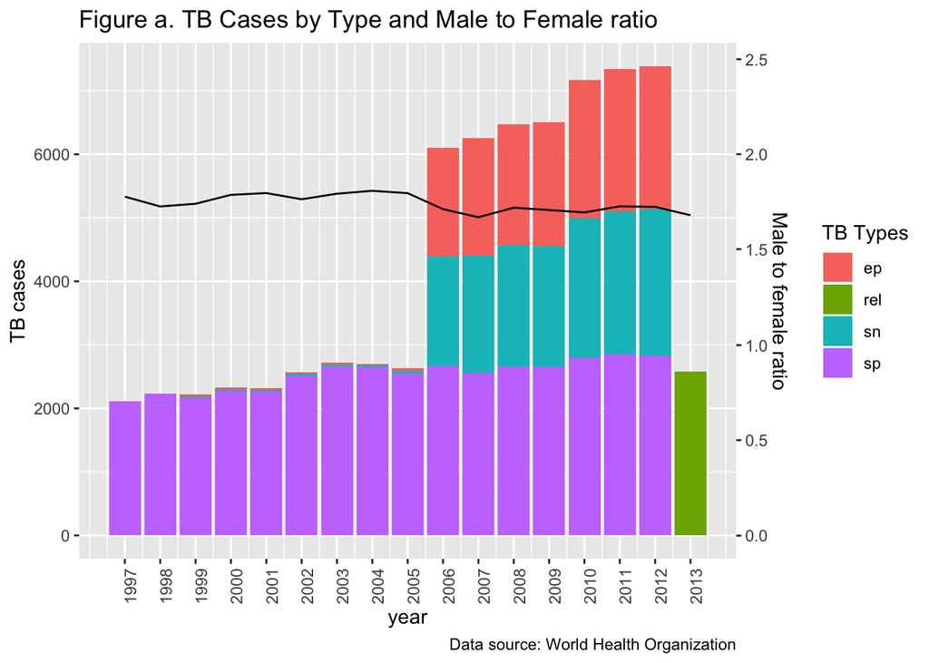

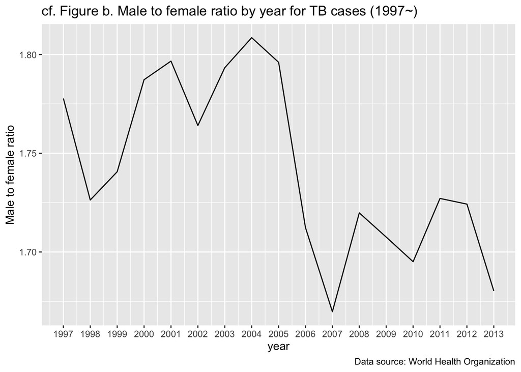

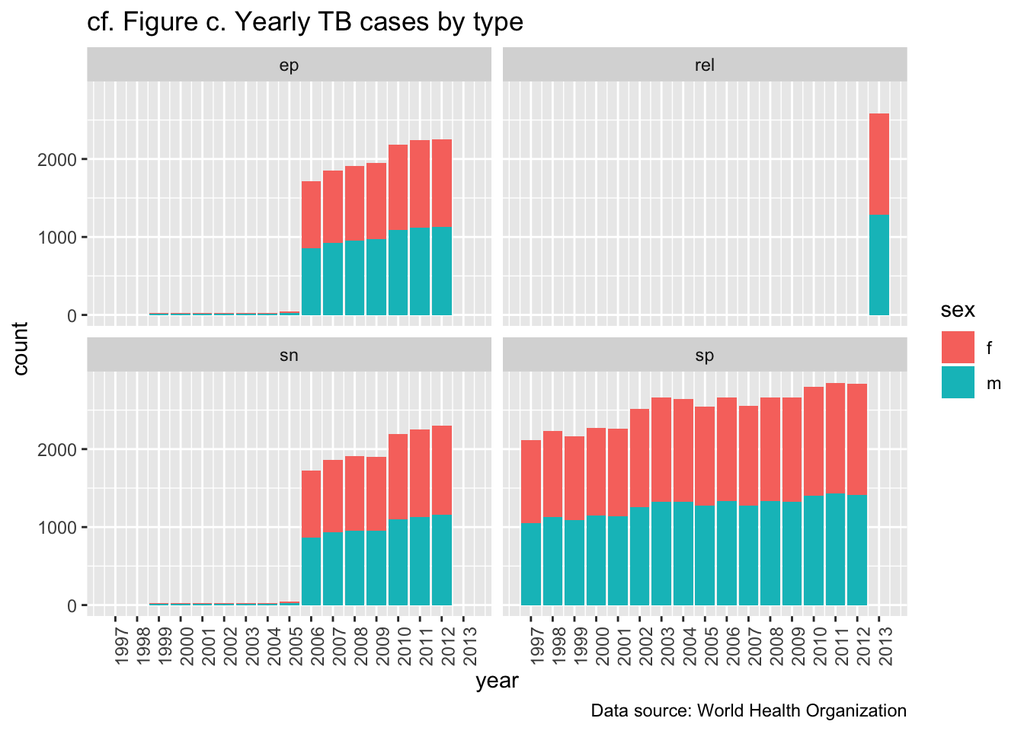

- So, we need further analysis for TB types and genders, other factors to figure out what is driving the gender associated difference with TB cases.
- Difference could also possibly arise from country specific factors, since natural gender ratio cannot be a main reason driving gender difference. (The value for the entire world population is 1.01 males/female, with 1.07 at birth, 1.06 for those under 15, 1.02 for those between 15 and 64, and 0.78 for those over 65.)
- I would specifically focus on TB cases conditioning on differenct countries for further analysis.
- resource: https://en.wikipedia.org/wiki/Human_sex_ratio
- resource: https://www.datanovia.com/en/blog/ggplot-axis-ticks-set-and-rotate-text-labels/
- resource: https://rpubs.com/MarkusLoew/226759

# 2 R4DS Chapter 13 Joins part 1

**1. Compute the average delay by destination, then join on the airports data frame so you can show the spatial distribution of delays.**

```r
not_cancelled <-
  flights %>%
  filter(!is.na(dep_delay), !is.na(arr_delay)) %>%
  filter(dest != "HNL", dest != "ANC")

(mapping <-
not_cancelled %>%
  group_by(dest) %>%
  summarise(delay = mean(arr_delay)) %>%
  inner_join(airports, by = c(dest = "faa")))
```

```
## # A tibble: 98 x 9
##    dest  delay name                 lat    lon   alt    tz dst   tzone
##    <chr> <dbl> <chr>              <dbl>  <dbl> <dbl> <dbl> <chr> <chr>
##  1 ABQ    4.38 Albuquerque Inter…  35.0 -107.   5355    -7 A     America/D…
##  2 ACK    4.85 Nantucket Mem       41.3  -70.1    48    -5 A     America/N…
##  3 ALB   14.4  Albany Intl         42.7  -73.8   285    -5 A     America/N…
##  4 ATL   11.3  Hartsfield Jackso…  33.6  -84.4  1026    -5 A     America/N…
##  5 AUS    6.02 Austin Bergstrom …  30.2  -97.7   542    -6 A     America/C…
##  6 AVL    8.00 Asheville Regiona…  35.4  -82.5  2165    -5 A     America/N…
##  7 BDL    7.05 Bradley Intl        41.9  -72.7   173    -5 A     America/N…
##  8 BGR    8.03 Bangor Intl         44.8  -68.8   192    -5 A     America/N…
##  9 BHM   16.9  Birmingham Intl     33.6  -86.8   644    -6 A     America/C…
## 10 BNA   11.8  Nashville Intl      36.1  -86.7   599    -6 A     America/C…
## # … with 88 more rows
```

- resource : https://austinwehrwein.com/digital-humanities/creating-a-density-map-in-r-with-zipcodes/

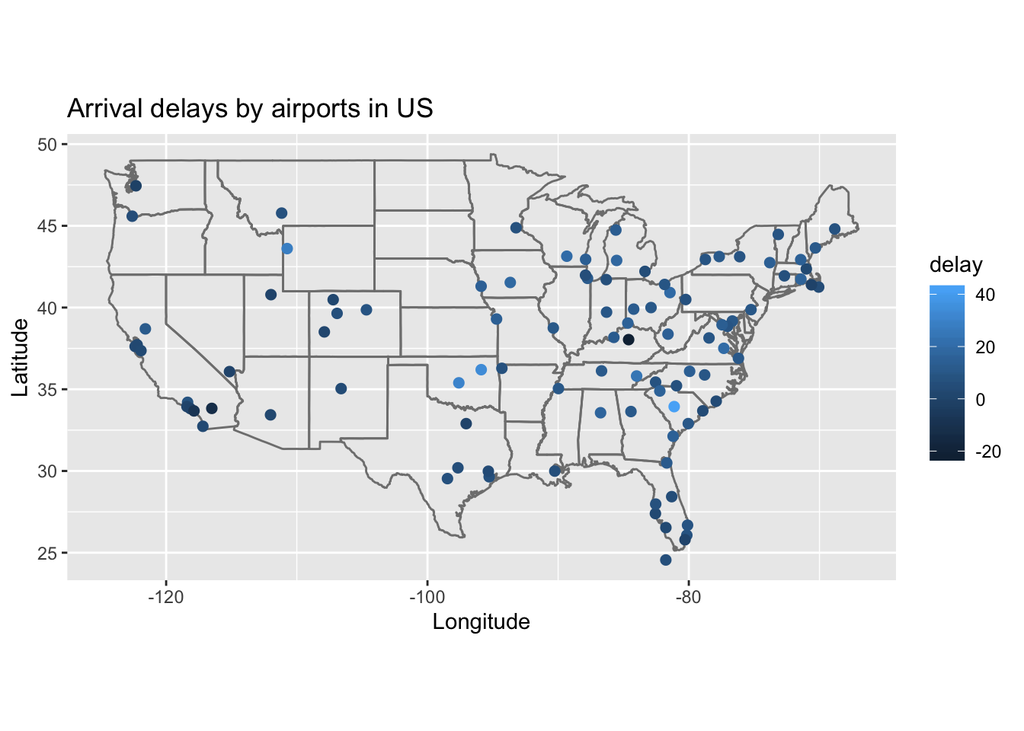

```r
mapping %>%
  ggplot() +
  borders("state") +
  geom_point(aes(lon, lat, color = delay), size = 2) +
  coord_quickmap() +
  labs(title = "Arrival delays by airports in US", x = "Longitude", y = "Latitude")
```

2. Add the location of the origin and destination (i.e. the lat and lon) to the flights data frame.

```r
flights %>%
  left_join(airports, by = c("origin" = "faa")) %>%
  left_join(airports, by = c("dest" = "faa")) %>%
  select(origin, dest, lon.x, alt.x, lon.y, alt.y)
```

```
## # A tibble: 336,776 x 6
##    origin dest  lon.x alt.x lon.y alt.y
##    <chr>  <chr> <dbl> <dbl> <dbl> <dbl>
##  1 EWR    IAH   -74.2    18 -95.3    97
##  2 LGA    IAH   -73.9    22 -95.3    97
##  3 JFK    MIA   -73.8    13 -80.3     8
##  4 JFK    BQN   -73.8    13  NA      NA
##  5 LGA    ATL   -73.9    22 -84.4  1026
##  6 EWR    ORD   -74.2    18 -87.9   668
##  7 EWR    FLL   -74.2    18 -80.2     9
##  8 LGA    IAD   -73.9    22 -77.5   313
##  9 JFK    MCO   -73.8    13 -81.3    96
## 10 LGA    ORD   -73.9    22 -87.9   668
## # … with 336,766 more rows
```

- **Is each plane is flown by a single airline?**
  - No, there are planes flown by more than one airline.
  - For instance, `N146PQ` is flown by 2 airlines, 9E and EV.
  - (cf. Planes are identified by `tailnum`, since it’s an ID that follows the plane regardless of ownership.)

```r
not_cancelled %>%
  filter(!is.na(tailnum)) %>%
  filter(tailnum == "N146PQ") %>%
  select(carrier, tailnum)
```

```
## # A tibble: 38 x 2
##    carrier tailnum
##    <chr>   <chr>
##  1 9E      N146PQ
##  2 9E      N146PQ
##  3 EV      N146PQ
##  4 EV      N146PQ
##  5 EV      N146PQ
##  6 EV      N146PQ
##  7 EV      N146PQ
##  8 9E      N146PQ
##  9 9E      N146PQ
## 10 9E      N146PQ
## # … with 28 more rows
```

```r
not_cancelled %>%
  filter(!is.na(tailnum)) %>%
  group_by(tailnum) %>%
  summarise(count_owners = n_distinct(carrier)) %>%
  filter(count_owners > 1)
```

```
## # A tibble: 17 x 2
##    tailnum count_owners
##    <chr>          <int>
##  1 N146PQ             2
##  2 N153PQ             2
##  3 N176PQ             2
##  4 N181PQ             2
##  5 N197PQ             2
##  6 N200PQ             2
##  7 N228PQ             2
##  8 N232PQ             2
##  9 N933AT             2
## 10 N935AT             2
## 11 N977AT             2
## 12 N978AT             2
## 13 N979AT             2
## 14 N981AT             2
## 15 N989AT             2
## 16 N990AT             2
## 17 N994AT             2
```

- **How many planes change ownership within the nycflight13 dataset?**
  - 17 planes were owned by 2 carriers within nycflight13 dataset.
  - This implies that 17 planes changed their ownership.

```r
flights %>%
  filter(!is.na(tailnum)) %>%
  group_by(tailnum) %>%
  summarise(count_owners = n_distinct(carrier)) %>%
  filter(count_owners >1)
```

```
## # A tibble: 17 x 2
##    tailnum count_owners
##    <chr>          <int>
##  1 N146PQ             2
##  2 N153PQ             2
##  3 N176PQ             2
##  4 N181PQ             2
##  5 N197PQ             2
##  6 N200PQ             2
##  7 N228PQ             2
##  8 N232PQ             2
##  9 N933AT             2
## 10 N935AT             2
## 11 N977AT             2
## 12 N978AT             2
## 13 N979AT             2
## 14 N981AT             2
## 15 N989AT             2
## 16 N990AT             2
## 17 N994AT             2
```

> Questiotion: Is there a relationship between the age of a plane and its delays?

> Query

```r
planes_rename <-
  planes %>%
  rename(manufactured_in = year)
planes_rename
```

```
## # A tibble: 3,322 x 9
##    tailnum manufactured_in type  manufacturer model engines seats speed
##    <chr>             <int> <chr> <chr>        <chr>   <int> <int> <int>
##  1 N10156             2004 Fixe… EMBRAER      EMB-…       2    55    NA
##  2 N102UW             1998 Fixe… AIRBUS INDU… A320…       2   182    NA
##  3 N103US             1999 Fixe… AIRBUS INDU… A320…       2   182    NA
##  4 N104UW             1999 Fixe… AIRBUS INDU… A320…       2   182    NA
##  5 N10575             2002 Fixe… EMBRAER      EMB-…       2    55    NA
##  6 N105UW             1999 Fixe… AIRBUS INDU… A320…       2   182    NA
##  7 N107US             1999 Fixe… AIRBUS INDU… A320…       2   182    NA
##  8 N108UW             1999 Fixe… AIRBUS INDU… A320…       2   182    NA
##  9 N109UW             1999 Fixe… AIRBUS INDU… A320…       2   182    NA
## 10 N110UW             1999 Fixe… AIRBUS INDU… A320…       2   182    NA
## # … with 3,312 more rows, and 1 more variable: engine <chr>
```

```r
age_delay <-
not_cancelled %>%
  left_join(planes_rename, by = "tailnum") %>%
  select(manufactured_in, dep_delay, arr_delay) %>%
  group_by(manufactured_in) %>%
  filter(!is.na(manufactured_in)) %>%
  summarise(ave_dep_delay = mean(dep_delay),
            ave_arr_delay = mean(arr_delay))
```

> Result:
- Is there a relationship between the age of a plane and its delays?

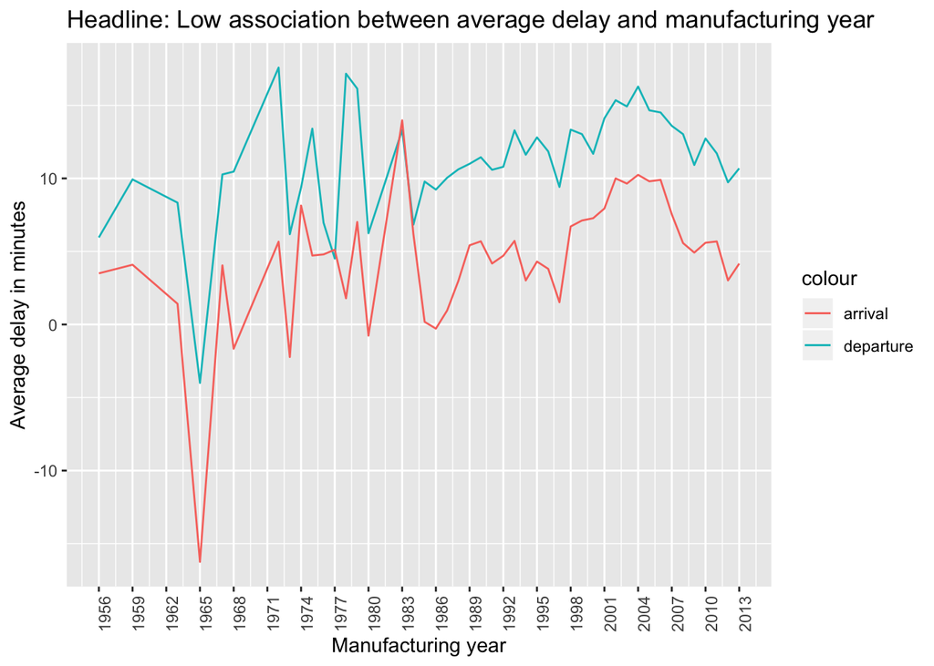

- resource : https://www.datanovia.com/en/blog/how-to-create-a-ggplot-with-multiple-lines/

```r
cor(age_delay$ave_dep_delay, age_delay$ave_arr_delay)
```

```
## [1] 0.7315164
```

```r
summary(lm(ave_dep_delay ~ manufactured_in, data = age_delay))
```

```
##
## Call:
## lm(formula = ave_dep_delay ~ manufactured_in, data = age_delay)
##
## Residuals:
##      Min       1Q   Median       3Q      Max
## -12.4375  -1.5244  -0.0571   1.6880   8.3680
##
## Coefficients:
##                  Estimate Std. Error t value Pr(>|t|)
## (Intercept)     -209.9092    65.4456  -3.207  0.00250 **
## manufactured_in    0.1111     0.0329   3.377  0.00154 **
## ---
## Signif. codes:  0 '***' 0.001 '**' 0.01 '*' 0.05 '.' 0.1 ' ' 1
##
## Residual standard error: 3.409 on 44 degrees of freedom
## Multiple R-squared:  0.2059, Adjusted R-squared:  0.1878
## F-statistic: 11.41 on 1 and 44 DF,  p-value: 0.00154
```

```r
head_flights <-
    flights %>%
    head(100) %>%
    left_join(weather, by = "year")

system.time(
  {head_flights <-
    flights %>%
    head(100) %>%
    left_join(weather, by = "year")})
```

```
##    user  system elapsed
##   0.836   0.204   1.195
```

```r
dim(head_flights)
```

```
## [1] 2611500      33
```

6. **Describe the result of using left_join to merge flights and weather based on year.**
- 8,794,905,240 rows will be created after left_join to merge flights and weather based on year.
  - 100:2611500=336776:x
  - x = 2611500*336776/100
- Since this is very heavy command for R to process, it will take long time to process the joining command.

```r
nrow(weather)
```

```
## [1] 26115
```

```r
nrow(head_flights)
```

```
## [1] 2611500
```

```r
nrow(flights)
```

```
## [1] 336776
```

```r
2611500*336776/100
```

```
## [1] 8794905240
```